# 3 - run_isobxr()

### Forcing initial delta values

By default, the `run_isobxr` function sets the initial delta values of all boxes at 0 ‰.

It is possible to manually overwrite the initial delta values of one, several or all boxes for a given run performed by `run_isobxr`.  
It is done by defining a data frame structured as follows.

```r
FORCING_DELTA <-
  data.frame(BOXES_ID = c("BOX_1", "...", "BOX_i", "..."),
             DELTA_INIT = c("updated_delta_1", "...", "updated_delta_i", "..."))

FORCING_DELTA
```

```
#>   BOXES_ID      DELTA_INIT
#> 1    BOX_1 updated_delta_1
#> 2      ...             ...
#> 3    BOX_i updated_delta_i
#> 4      ...             ...
```

For the 3-boxes closed system model (ABC), in order to force initial isotope composition of box A to -1‰, and leave B and C initial values at 0‰, the data frame should be structured as follows:

```r
FORCING_DELTA <-
  data.frame(BOXES_ID = c("A"),
             DELTA_INIT = c(-1))

FORCING_DELTA
```

```
#>   BOXES_ID DELTA_INIT
#> 1        A         -1
```

### Forcing fractionation coefficients

By default, the `run_isobxr` function sets the isotope fractionation coefficients at the values found in the coefficients list specified by user.

It is possible to manually overwrite the fractionation coefficients of one, several or all pairs of boxes for a given run performed by `run_isobxr`.  
It is done by defining a data frame structured as follows.

```r
FORCING_ALPHA <-
  data.frame(FROM = c("BOX_i", "..."),
             TO = c("BOX_j", "..."),
             ALPHA = c("new_coeff_value", "..."),
             FROM_TO = c("BOX_i_BOX_j", "..."))

FORCING_ALPHA
```

```
#>    FROM    TO           ALPHA     FROM_TO
#> 1 BOX_i BOX_j new_coeff_value BOX_i_BOX_j
#> 2   ...   ...             ...         ...
```

For the 3-boxes closed system model (ABC), in order to force the fractionation coefficient associated to the flux of Ca from box A to B to the value of 1.02, the data frame should be structured as follows:

```r
FORCING_ALPHA <-
  data.frame(FROM = c("A"),
             TO = c("B"),
             ALPHA = c(1.02),
             FROM_TO = c("A_B"))

FORCING_ALPHA
```

```
#>   FROM TO ALPHA FROM_TO
#> 1    A  B  1.02     A_B
```

### Rayleigh distillation models

It is possible to overwrite isotope fractionation coefficients by defining their values as the result of Rayleigh type isotope distillation in the context of a fractional exchange at an interface.

We consider here the case of the loss of element X from a box A to a box C through an interface box B, all possibly part of a bigger box model system.

We suppose that the apparent fractionation coefficient $\alpha_{A \to C}$ associated to this flux $F_{A \to C}$ results from a Rayleigh type distillation occurring during the fractional exchange of element X at the interface box B.

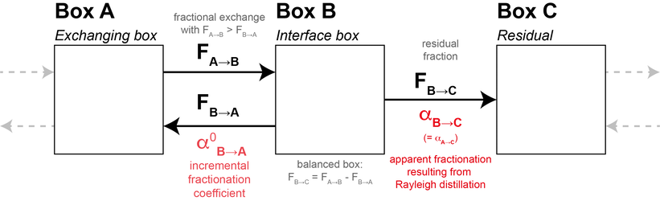

In this situation, the box A exchanges element X with box B (and possibly other boxes).

This is a fractional exchange, *i.e.* during this exchange, box A sends more of element X to box B than B sends back ($F_{A \to B} > F_{B \to A}$).

As we consider box B to be balanced, it loses the difference to box C: $F_{B \to C} = F_{A \to B} - F_{B \to A}$.

As a result, box A loses a total of $F_{B \to C}$ of element X per time unit.

We suppose here that the $F_{A \to B}$ that feeds box B is associated to no isotope fractionation.

On the other hand, we suppose that the $F_{B \to A}$ flux corresponding to the fractional loss of element X from interface box B, and returning to box A, is associated to an *equilibrium* or *incremental* isotope fractionation ($\alpha^0 _{B \to A}$).

The Rayleigh distillation model of isotopes thus predicts the following:

$$R_{C} = R_{C, t_0} \dfrac{F_{B \to C}}{F_{A \to B}}^{\alpha^0 _{B \to A} - 1}$$

The $R_{C, t_0}$ corresponds to the isotope ratio of the element X in box B before any exchange with box A occurs. It is thus equivalent to $R_{A}$ since the box B only input is *via* the $F_{A \to B}$ flux.

We thus can write the following definition of $\alpha_{B \to C}$ (equivalent here to $\alpha_{A \to C}$):

$\alpha_{B \to C} = \dfrac{R_{C}}{R_{A}} = \dfrac{F_{B \to C}}{F_{A \to B}}^{\alpha^0 _{B \to A} - 1}$

The `run_isobxr` function here takes as an optional input the data frame structured as follows:

```r
FORCING_RAYLEIGH <-
  data.frame(XFROM = c("B"), # Define the B>C flux at numerator
             XTO = c("C"),
             YFROM = c("A"), # Define the A>B flux at denominator
             YTO = c("B"),
             AFROM = c("B"), # Define the resulting fractionation coefficient
             ATO = c("C"),
             ALPHA_0 = c("a0") # Define the value of incremental B>A coefficient
  )

FORCING_RAYLEIGH
```

```
#>   XFROM XTO YFROM YTO AFROM ATO ALPHA_0
#> 1     B   C     A   B     B   C      a0
```

The `run_isobxr` function will in this case overwrite the value of $\alpha_{B \to C}$ set in **isobxr master file** or using the FORCING_ALPHA parameter.

Indeed, if the user forced a new value for $\alpha_{B \to C}$ using the FORCING_ALPHA parameter, the `run_isobxr` function will prioritize the FORCING_RAYLEIGH parameter.

It is possible to define several Rayleigh distillation apparent fractionation coefficients in a given model.  
This is done by adding rows to this data frame.